# 05. 잠재변수가 있는 구조방정식 모형

## 05.01. 구조방정식모형의 구성

- **관찰변수 / 측정변수** : 측정의 정의가 명확하게 내려져 잇어, 그 값들이 직접 관찰된 변수
- **잠재변수 : 직접 측정이나 관찰이 불가능하고 관찰변수들의 저변에 잠재되어 있는 변수**

### 측정모형과 구조모형

- 잠재변수가 있는 구조방정식 모형의 체제는 관찰변수와 잠재변수들 간의 인과관계를 나타내는 측정모형과 잠재변수들 간의 인과관계를 나타내는 구조모형으로 구분
- **측정모형은 잠재변수들이 관찰변수들을 통해 어떻게 측정되어지는가를 규정하며, 관찰된 변수들이 추상적/가설적 개념을 구축함에 있어 측정변수로서의 특성들이 관심대상에 포함**
  - **측정과정에서 불가피하게 수반되는 측정오차 등이 반영**
  - 구조방정식모형을 설정함에 있어 측정모형의 타당성이 일차적으로 중요

### 잠재변수 규정시 주의사항

- 구조방정식모형에서는 관찰변수들을 통해 잠재변수를 비추어보는 형식의 우회적 접근이 이루어짐
  - 관찰변수를 잠재변수에 대한 지지자 (indicator)
1. **잠재변수는 단순히 관찰변수들의 묶음을 의미하거나 관찰변수들에 대한 설명이 아님**
2. **잠재변수는 단일한 개념(의미)을 나타내도록 규정되어야 함**
   - 변수들이 각각 서로 다른 개념들을 측정할 수 있기 때문
   - 복합적 의미를 가지는 잘못된 잠재변수 : [행복감, 자신감, 우울, 불안] $\rightarrow$ 심리상태
3. 잠재변수들 간의 인과(연관)관계를 묘사하는 경로계수들은 방향성을 가지고 해석할 수 있어야 하므로, 크기를 말할 수 있어야 함
   - 크기가 정의되지 않는 잘못된 잠재변수 : [성별, 나이, 직업, 학력] $\rightarrow$ 일반적 특성
4. 반영적 지표라는 개념과 관련하여, 하나의 잠재변수를 규정하는 관찰변수들은 동일한 개념을 측정한다고 말할 수 있어야 함
   - [성별, 나이] $\rightarrow$ 일반적으로 서로 관련성이 없금 $\rightarrow$ 동일한 잠재변수를 측정한다고 주장할 수 없음

### 반영적 지표와 조형적 지표

- 잠재변수로부터 관찰변수 방향으로 화살표가 존재 $\rightarrow$ 관찰변수의 의미가 반영적 지표 (reflective indicator)
- 관찰변수로부터 잠재변수 방향으로 화살표가 존재 $\rightarrow$ 잠재변수에 대한 관찰변수의 의미가 조형적 지표 (formative indicator)

#### 반영적 지표 (reflective indicator)

- **관찰변수의 값이 잠재변수의 영향을 받아 결정되는 구조**
  - **잠재변수가 관찰변수의 원인임을 가정**
- **관찰변수의 값이 잠재변수들의 영향으로 인하여 변화될 수 있기에, 관찰변수들 사이에 상관관계가 높을 수 있음**
  - 관찰변수의 변화가 잠재변수인 개념을 변화시키지 않는다는 특징
- **관찰변수들은 해당 잠재변수의 함수이므로, 동일한 잠재변수의 관찰변수 값들 사이에는 내적 일관성이 기대됨**
  - **측정모형과 관련된 계수들의 통계적 유의성은 구조방정식모형의 주요 관심 대상**
- 전통적인 형태의 구조방정식모형에서는 잠재벼순가 모두 반영적 지표임을 가정

  (잠재변수들이 반영적 지표만으로 구성된 모형을 '인자-기반 구조방정식모형')
  - **이 경우 잠재변수는 요인(factor)의 의미를 가짐**

**반영적 지표**

$$\begin{cases} 국어점수 = \lambda_1 언어능력+\delta_1\\ 영어점수 = \lambda_2 언어능력+\delta_2\\ 한문점수 = \lambda_3 언어능력+\delta_3\\ \end{cases}$$

- 각 $\lambda$는 각 관찰변수가 잠재변수와 얼마나 관련되어 있는지를 나타내며, (인자적재값 (factor loading)또는 요인 부하량)

  각 $\delta$는 관찰변수의 측정값 중 잠재변수와 구별되는 부분 (측정오차 등)을 나타내며, 해당 관찰변수의 특수성 또는 유일성으로 부름

#### 조형적 지표 (formative indicator)

- **관찰변수가 잠재변수의 값을 결정하는 구조**
  - **관찰변수가 잠재변수를 형성하는 원인임을 가정**
- **관찰변수의 변화에 잠재변수가 변화하지만, 잠재변수의 변화가 관찰변수의 변화를 수반하지 않음**
- **잠재변수에 의해 공통적으로 영향을 받아 관찰변수의 값이 결정되는 것이 아니기에, 관찰변수들 간의 높은 상관관계와 내적일치도를 반드시 필요로 하지 않음**
- **잠재변수가 조형적 지표로 구성되는 대표적인 모형으로는 PLS (partial least squares)가 있으며, 조형적 지표가 포함된 모형을 '성분-기반 구조방정식모형'**
  - 이 경우 잠재변수는 성분, 지수, 점수의 의미를 가짐

**조형적 지표**

$$SES(사회경제적\;지위) = w_1 소득수준 + w_2 직업수준 + w_3 학력수준$$

- **잠재변수는 관찰변수들의 가중합으로 정의되며, 여기에서 각 $w$는 각 관찰변수가 붙는 가중치를 나타냄**
- 사전에 정의된 가중치를 이용하여 잠재변수의 값을 계산하고, 이후의 분석에서 하나의 점주(성분)로 취급하여 사용

### 측정모형과 관찰변수의 측정

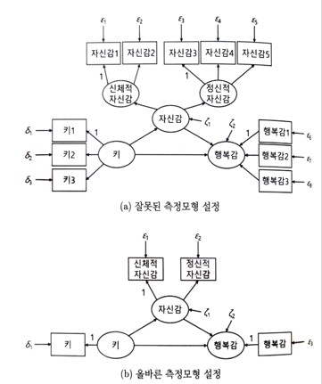

- (a)에서 키에 대한 한 번의 측정값 또는 행복감의 한 문항에 대한 측정값은 신뢰할 수 없기에 회귀분석, 분산분석, 구조방정식모형과 같은 통계분석의 직접적인 대상이 될 수 없음
- **구조방정식모형은 관찰변수(측정변수)로 설정된 변수들의 분산과 공분산이 직접적인 분석대상이 되므로, (a)와 같이 설정하면 매우가 불안정**

## 05.02. 초기모형

- **외생 잠재변수 (Exogenous Latent Variable)** : ACHMOT (성취동기), TSSE (직무관련 자존감), VERBINT (대화능력)
- **내생 잠재변수 (Endogenous Latent Variable)** : PERFORM (업무능력), JOBSATIS (직무 만족도)
- **관찰변수** :
  - Achmot (성취동기) : 성취동기1, 성취동기2, 성취동기3
  - Tsse (직무관련 자존감) : 직무관련 자존감1, 직무관련 자존감2
  - Verbint (언어적 기능)
  - Perform (업무능력)
  - Jobsatis (직무만족도)
- **내생 오차변수** : $\zeta_1, \zeta_2$
- **측정 오차변수** : $\delta_1, \delta_2, \delta_3, \delta_4, \dots, \epsilon_1, \epsilon_2. \epsilon_3$

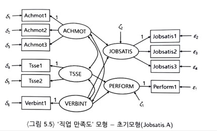

**잠재변수들의 인과관계**

$$\begin{cases} PERFORM = \gamma_{12}TSSE + \gamma_{13}VERBINT+\zeta_{1}\\ JOBSATIS = \gamma_{21}ACHMOT + \gamma_{23}VERBINT+\zeta_{2}\\ \end{cases}$$

```r
library(lavaan)
library(sem)
library(semPlot)
library(semptools)
library(psych)
library(tidyverse)
```

```r
detach("package:sem",unload=TRUE)
```

```r
Jobsatis <- read.csv(paste0(getwd(), "/Data/Jobsatis.csv"), header = TRUE)
Jobsatis %>% head
```

A data.frame: 6 × 10

|  | Achmot1 <dbl> | Achmot2 <dbl> | Achmot3 <dbl> | Tsse1 <dbl> | Tsse2 <dbl> | Verbint1 <dbl> | Perform1 <dbl> | Jobsatis1 <dbl> | Jobsatis2 <dbl> | Jobsatis3 <dbl> |
| --- | --- | --- | --- | --- | --- | --- | --- | --- | --- | --- |
| 1 | 4.7 | 5.8 | 5.6 | 5.4 | 4.3 | 5.5 | 5.9 | 4.8 | 5.8 | 6.7 |
| 2 | 6.9 | 6.1 | 3.3 | 5.1 | 5.4 | 6.2 | 5.5 | 5.6 | 7.6 | 5.0 |
| 3 | 4.7 | 4.4 | 3.5 | 5.4 | 4.8 | 5.3 | 4.8 | 4.4 | 5.9 | 3.6 |
| 4 | 5.0 | 4.5 | 5.2 | 5.4 | 5.1 | 8.0 | 5.7 | 5.3 | 6.0 | 4.1 |
| 5 | 3.5 | 4.8 | 4.3 | 5.2 | 6.7 | 5.9 | 4.4 | 4.9 | 6.0 | 3.8 |
| 6 | 3.1 | 4.9 | 4.7 | 5.5 | 5.2 | 4.5 | 5.1 | 6.5 | 4.4 | 5.4 |

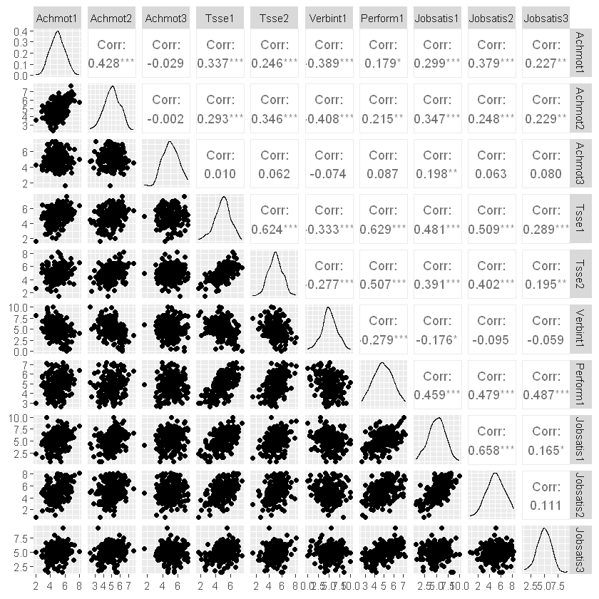

```r
GGally::ggpairs(Jobsatis)
```

```r
Jobsatis.A <- "
    # easurement
    ACHMOT = ~ Achmot1 + Achmot2 + Achmot3
    TSSE = ~ Tsse1 + Tsse2
    VERBINT = ~ Verbint1
    PERFORM = ~ Perform1
    JOBSATIS = ~ Jobsatis1 + Jobsatis2 + Jobsatis3

    # regression
    PERFORM ~ TSSE + VERBINT
    JOBSATIS ~ ACHMOT + VERBINT

    # error covariance (PERFORM과 JOBSATIS의 편상관이 존재하지 않음을 가정하므로, 편상관이 0이라는 것을 설정)
    PERFORM ~~ 0 * JOBSATIS
"
```

```r
Jobsatis.A.fit <- sem(Jobsatis.A, Jobsatis)
```

- 일부 변수들의 분산이 음의 값으로 추정됨 $\rightarrow$ 추정치가 이론적이느 범위를 넘어서는 상황 'Heywood 상황'
  - 어떤 변수의 분산이 음수가 되는 경우
    - 오차변수의 분산이 음수로 추정되는 경우, 오차변수의 분산을 아주 작은 수치로 고정하여 분석 (0.001)
    - 이 경우, 적합도나 추정치가 좋지 않은 결과를 보일 수 있음
  - 상관계수의 절댓값이 1보다 큰 경우
  - SMR가 1을 넘는 경우 등
  - 원인은 다양하지만, 모형이 데이터를 잘 표현하지 못하는 경우에 많이 나타남

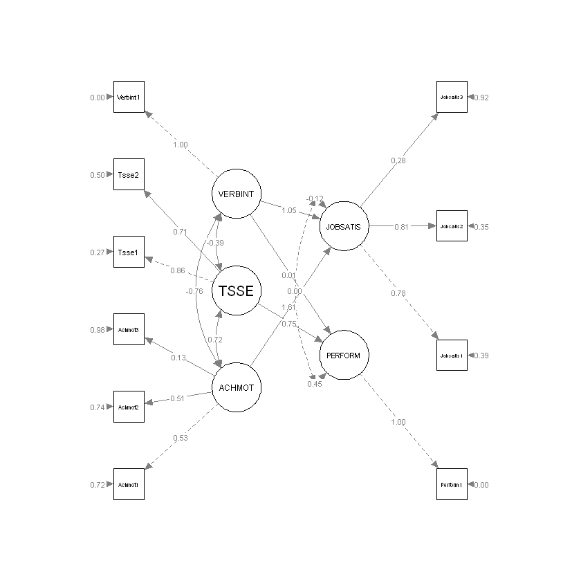

```r
semPaths(Jobsatis.A.fit, whatLabels = "std", style = "lisrel", nCharNodes = 0, rotation = 2)
```

## 05.03. 잠재변수에 대한 측정단위 규정

- 외생 잠재변수에 대한 측정모형

$$\begin{cases} Achmot1 = \lambda^x_{11} ACHMOT + \delta_1\\ Achmot2 = \lambda^x_{21} ACHMOT + \delta_2\\ Achmot3 = \lambda^x_{31} ACHMOT + \delta_3\\ Tsse1 = \lambda^x_{42} TSSE + \delta_4\\ Tsse2 = \lambda^x_{52} TSSE+ \delta_5\\ Verbint1 = \lambda^x_{63} VERBINT + \delta_6\\ \end{cases}$$

- 내생 잠재변수에 대한 측정모형

$$\begin{cases} Perform1 = \lambda^y_{11}PERFORM + \epsilon_{1}\\ Jobsatis1 = \lambda^y_{22}JOBSATIS + \epsilon_{2}\\ Jobsatis2 = \lambda^y_{32}JOBSATIS + \epsilon_{3}\\ Jobsatis3 = \lambda^y_{42}JOBSATIS + \epsilon_{4}\\ \end{cases}$$

#### $\lambda^x_{ij}$와 $\lambda^y_{ij}$는 인자적재값 (factor loading)

- 관찰변수와 잠재변수가 가지는 연관관계의 정도를 나타냄

**잠재변수는 관찰되지 않은 것이기 때문에, 정해진 척도(scale)를 가지고 있지 않으며 그 측정단위가 임의적**

- 그러나 관련된 모수를 추정하고 경로계수의 상대적 비교나 모형의 적절한 해석을 위해서는 각 잠재변수를 특정한 단위로 규정하거나, 측정단위를 없앨 필요가 있음

#### 잠재변수에 대한 측정단위를 규정하기 위해서는 일반적으로 2가지 방법 중 하나 사용

#### 1. 인자적재값을 1로 고정

- 잠재변수의 측정단위를 규정하기 위해서 관찰변수 중의 어느 하나를 그 잠재변수에 대한 참조변수로 두어 해당하는 인자적재값을 0이 아닌 1로 고정하는 것
  - **이는 잠재변수의 측정단위가 참조 관찰변수의 측정단위와 같다고 가정하는 것**
  - 잠재변수의 측정단위가 서로 다른 경우, 잠재변수들 간의 인과관계를 나타내는 회귀게수들의 크기를 상대비교하기가 여려울 수도 있음 $\rightarrow$ 표준화추정치 (standardized estimate)에 의해서 추정치들을 해석
- **`sem()`함수에서는 기본적으로 인자적재값을 1로 고정시키는 방법을 적용**

```r
print(summary(Jobsatis.A.fit, fit.measures = TRUE, rsquare = TRUE, standardized = TRUE))
```

```
lavaan 0.6.16 ended normally after 71 iterations

  Estimator                                         ML
  Optimization method                           NLMINB
  Number of model parameters                        26

  Number of observations                           200

Model Test User Model:

  Test statistic                               117.210
  Degrees of freedom                                29
  P-value (Chi-square)                           0.000

Model Test Baseline Model:

  Test statistic                               689.456
  Degrees of freedom                                45
  P-value                                        0.000

User Model versus Baseline Model:

  Comparative Fit Index (CFI)                    0.863
  Tucker-Lewis Index (TLI)                       0.788

Loglikelihood and Information Criteria:

  Loglikelihood user model (H0)              -2937.852
  Loglikelihood unrestricted model (H1)      -2879.247

  Akaike (AIC)                                5927.703
  Bayesian (BIC)                              6013.460
  Sample-size adjusted Bayesian (SABIC)       5931.089

Root Mean Square Error of Approximation:

  RMSEA                                          0.123
  90 Percent confidence interval - lower         0.100
  90 Percent confidence interval - upper         0.147
  P-value H_0: RMSEA <= 0.050                    0.000
```

[output cut: 66 more lines]

```

R-Square:
                   Estimate
    Achmot1           0.305
    Achmot2           0.279
    Achmot3           0.016
    Tsse1             0.789
    Tsse2             0.505
    Verbint1          1.000
    Perform1          1.000
    Jobsatis1         0.602
    Jobsatis2         0.639
    Jobsatis3         0.105
    PERFORM           0.489
    JOBSATIS             NA
```

#### 2. 잠재변수들의 표준화

- 잠재변수의 분산이 1이 되도록 표준화되어 있다고 가정하여, 측정단위 자체를 없애버림으로써, 잠재변수가 취하는 값이 단순한 숫자가 되도록 하는 것
- `sem()`함수에 이를 적용할 때, 문제가 발생하여 해를 구하지 못하는 경우 존재

```r
Jobsatis.A.fit <- sem(Jobsatis.A, data= Jobsatis, std.lv = TRUE)
```

#### 어떤 방식이든 잠재변수의 측정단위를 규정하지 않으면, 추정치를 구할 수 없게 되는 식별불능 문제에 빠지게 됨

## 05.04. 단일 지시자 문제

- 측정모형이 식별되기 위해서는 한 잠재변수당 2개 이상의 관찰변수가 규정되어야 함
  - 그러나 현실적으로 하나의 잠재변수를 1개의 관찰변수만으로 규정해야 하는 경우가 존재 $\rightarrow$ 단일지시자 (single indicator)문제
  - 이 경우에도 식별불능의 문제 발생 가능
- 단일 지시자 문제 발생 경우, 보통 오차변수의 분산을 특정 값으로 고정하여 식별문제를 해결

### 1. 오차변수의 분산을 0으로 고정

- **`sem()`함수에서는 단일지시자 문제에서 기본적으로 오차변수의 분산을 0으로 고정**
- **잠재변수 VERBINT와 PERFORM에 대한 측정오차가 0으로 가정함 $\rightarrow$ 두 잠재변수에 대해 관찰변수와 잠재변수가 실제 동일한 것으로 간주**

```r
library(tidymodels)
```

```r
(summary(Jobsatis.A.fit, fit.measures = TRUE, rsquare = TRUE, standardized = TRUE))$pe %>%
    filter(op == "~~") %>%
    filter(lhs %in% c("Verbint1", "Perform1"))
```

A data.frame: 2 × 11

| lhs <chr> | op <chr> | rhs <chr> | exo <int> | est <dbl> | se <dbl> | z <dbl> | pvalue <dbl> | std.lv <dbl> | std.all <dbl> | std.nox <dbl> |
| --- | --- | --- | --- | --- | --- | --- | --- | --- | --- | --- |
| Verbint1 | ~~ | Verbint1 | 0 | 0 | 0 | NA | NA | 0 | 0 | 0 |
| Perform1 | ~~ | Perform1 | 0 | 0 | 0 | NA | NA | 0 | 0 | 0 |

### 측정의 신뢰도를 이용

- 관찰변수가 여러 항목들의 합(또는 평균)으로 측정된 경우 신뢰도(reliability) $\alpha$가 주어질 수 있음
  - 신뢰도의 정의에 의하면 $1-\alpha$는 측정값에서 측정오차가 차지하는 비중을 의미하므로, 측정오차의 분산을 다음과 같이 추정

$$측정오차의\;분산 = (1-\alpha) \times 관찰변수의\;분산$$

- 예를들어, 잠재변수 VERBINT를 측정하는 관찰변수 Verbint1의 여러 문항들의 합으로 측정되었고, 이에 대한 측정의 신뢰도가 $\alpha =0.85$라고 가정 시
  - 변수 Verbint1의 분산은 3.393이므로, 대응되는 오차변수 $\delta_6$의 분산을 다음과 같이 추정

  $$\hat{Var}(\delta_6)=(1-\alpha)\times\hat{Var}(Verbint1) = (1-0.85)\times3.393=0.509$$

```r
sd(Jobsatis$Verbint1)^2
```

3.39310150753769

- 관찰변수 Verbint1에 대응되는 오차변수 $\delta_6$에 대한 분산을 0.509로 고정하고, Perform1에 대응되는 오차변수 (\epsilon_1)에 대한 분산을 0으로 고정하는 예

```r
Jobsatis.A <- "
    # easurement
    ACHMOT = ~ Achmot1 + Achmot2 + Achmot3
    TSSE = ~ Tsse1 + Tsse2
    VERBINT = ~ Verbint1
    PERFORM = ~ Perform1
    JOBSATIS = ~ Jobsatis1 + Jobsatis2 + Jobsatis3

    # regression
    PERFORM ~ TSSE + VERBINT
    JOBSATIS ~ ACHMOT + VERBINT

    # error covariance
    PERFORM ~~ 0 * JOBSATIS

    # error variance
    Verbint1 ~~ 0.509 * Verbint1
    Perform1 ~~ 0 * Perform1
"
```

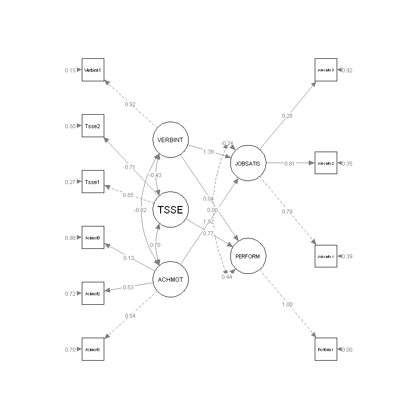

```r
Jobsatis.A.fit <- sem(Jobsatis.A, data = Jobsatis)
semPaths(Jobsatis.A.fit, whatLabels = "std", style = 'lisrel', nCharNodes = 0, rotation = 2)
```

```r
summary(Jobsatis.A.fit, fit.measures = TRUE, rsquare = TRUE, standardized = TRUE)$pe %>%
    filter(op == "~~", lhs == "Verbint1")
```

A data.frame: 1 × 11

| lhs <chr> | op <chr> | rhs <chr> | exo <int> | est <dbl> | se <dbl> | z <dbl> | pvalue <dbl> | std.lv <dbl> | std.all <dbl> | std.nox <dbl> |
| --- | --- | --- | --- | --- | --- | --- | --- | --- | --- | --- |
| Verbint1 | ~~ | Verbint1 | 0 | 0.509 | 0 | NA | NA | 0.509 | 0.1509893 | 0.1509893 |

## 05.05. 적합도 평가

- GFI를 제외한 대부분의 적합도 지수들이 기준에 미달

```r
tidy(fitMeasures(Jobsatis.A.fit)) %>%
    filter(names %in% c("chisq", "df", "gfi", "agfi", "cfi", "tli", "rmsea", "srmr"))
```

A tibble: 8 × 2

| names <chr> | x <lvn.vctr> |
| --- | --- |
| chisq | 124.95145196 |
| df | 30.00000000 |
| cfi | 0.85266408 |
| tli | 0.77899612 |
| rmsea | 0.12579842 |
| srmr | 0.06848699 |
| gfi | 0.90622819 |
| agfi | 0.82808501 |

- 수정지수 : 수정지수가 10보다도 큰 경로들이 여러개 존재

```r
modificationindices(Jobsatis.A.fit, sort = T) %>% filter(mi >= 10)
```

A lavaan.data.frame: 7 × 8

| lhs <chr> | op <chr> | rhs <chr> | mi <dbl> | epc <dbl> | sepc.lv <dbl> | sepc.all <dbl> | sepc.nox <dbl> |
| --- | --- | --- | --- | --- | --- | --- | --- |
| PERFORM | =~ | Jobsatis3 | 38.41113 | 0.6903350 | 0.7019178 | 0.5462611 | 0.5462611 |
| Jobsatis1 | ~~ | Jobsatis2 | 33.75412 | 2.4537540 | 2.4537540 | 2.4868270 | 2.4868270 |
| Perform1 | ~~ | Jobsatis3 | 33.24346 | 0.3801919 | 0.3801919 | NA | NA |
| Jobsatis2 | ~~ | Jobsatis3 | 14.82861 | -0.3979633 | -0.3979633 | -0.3590310 | -0.3590310 |
| PERFORM | =~ | Verbint1 | 13.98085 | -1.1349874 | -1.1540309 | -0.6285381 | -0.6285381 |
| TSSE | =~ | Jobsatis3 | 13.40191 | 0.7011507 | 0.6456707 | 0.5024873 | 0.5024873 |
| Verbint1 | ~~ | Perform1 | 11.47916 | -0.4918685 | -0.4918685 | NA | NA |

## 05.06. 확증적 인자분석을 이용한 측정모형 평가

- 관찰변수와 잠재변수의 수가 많고, 모형이 복잡한 구조를 가지는 경우, 모형의 적합도가 나쁠 때, 모형수정을 위해 어떤 부분을 먼저 검토해야 하는지 판단하기 어려운 경우가 존재 **$\rightarrow$ 측정모형과 구조모형을 구분하여 차례로 검토**

#### 확증적 인자모형 (confirmatory factor model)

- **잠재변수들을 모두 외생변수로만 고려하는 모형**
  - **따라서 모든 잠재변수들 간에 연관관계(양방향 화살표)로 설정되는 모형을 의미**

[figure not shown]

- 적합도의 관점에서는 잠재변수들 간에 연관관계 (양방향 화살표)를 설정하든 인과관계 (단방향 화살표)를 설정하든 차이가 없음
- 확증적 인자모형에서는 모든 잠재변수들이 서로 화살표로 연결되어 있으므로, 구조모형에서는 더 이상의 적합도 증가를 기대할 수 없게됨
  - 확증적 인자모형의 적합도가 나쁘게 나타난다면, 측정모형 부분만을 살펴봄으로써 모형수정의 범위를 좁힐 수 있음
  - 그리고 측정모형 부분에서 문제점을 수정한 후, 구조모형을 다시 원래대로 설정하고 수정지수 등을 이용하여 구조모형 부분에서의 문제점들을 검토
- **확증적 인자분석 (CFA)를 이용하면, 측정모형을 평가하고 수정하는 작업을 조금더 효율적으로 진행 가능**
  - 간단한 모형에 대해서는 이러한 절차를 수행하지 않아도 모형수정을 쉽게 진행할 수 있음

```r
Job_CFA.A <- "
    # measurement model
    ACHMOT = ~ Achmot1 + Achmot2 + Achmot3
    TSSE =~ Tsse1 + Tsse2
    VERBINT =~ Verbint1
    PERFORM =~ Perform1
    JOBSATIS =~ Jobsatis1 + Jobsatis2 + Jobsatis3
"
```

```r
Job_CFA.A.fit <- sem(Job_CFA.A, Jobsatis)
```

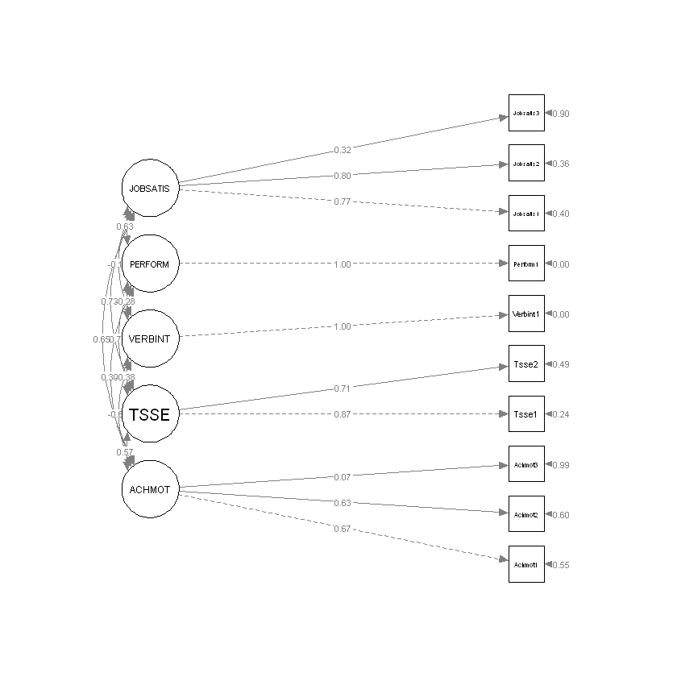

```r
semPaths(Job_CFA.A.fit, whatLabels = "std", style = "lisrel", nCharNodes = 0, rotation = 2)
```

- GFI를 제외한 대부분의 적합도가 미달

```r
tidy(fitMeasures(Job_CFA.A.fit)) %>%
    filter(names %in% c("chisq", "df", "gfi", "agfi", "cfi", "tli", "rmsea", "srmr"))
```

A tibble: 8 × 2

| names <chr> | x <lvn.vctr> |
| --- | --- |
| chisq | 107.88157539 |
| df | 27.00000000 |
| cfi | 0.87449627 |
| tli | 0.79082712 |
| rmsea | 0.12238492 |
| srmr | 0.06199574 |
| gfi | 0.91047120 |
| agfi | 0.81762652 |

- 계수 추정치

```r
summary(Job_CFA.A.fit, fit.measures = TRUE, rsquare = TRUE, standardized = TRUE)$pe %>%
    filter(op == "=~")
```

A data.frame: 10 × 11

| lhs <chr> | op <chr> | rhs <chr> | exo <int> | est <dbl> | se <dbl> | z <dbl> | pvalue <dbl> | std.lv <dbl> | std.all <dbl> | std.nox <dbl> |
| --- | --- | --- | --- | --- | --- | --- | --- | --- | --- | --- |
| ACHMOT | =~ | Achmot1 | 0 | 1.0000000 | 0.00000000 | NA | NA | 0.6582209 | 0.66731690 | 0.66731690 |
| ACHMOT | =~ | Achmot2 | 0 | 0.8858533 | 0.12940125 | 6.8457868 | 7.605694e-12 | 0.5830872 | 0.62875514 | 0.62875514 |
| ACHMOT | =~ | Achmot3 | 0 | 0.1087690 | 0.12291284 | 0.8849275 | 3.761957e-01 | 0.0715940 | 0.07151193 | 0.07151193 |
| TSSE | =~ | Tsse1 | 0 | 1.0000000 | 0.00000000 | NA | NA | 0.9442163 | 0.87430167 | 0.87430167 |
| TSSE | =~ | Tsse2 | 0 | 0.8145326 | 0.08073582 | 10.0888626 | 0.000000e+00 | 0.7690950 | 0.71350640 | 0.71350640 |
| VERBINT | =~ | Verbint1 | 0 | 1.0000000 | 0.00000000 | NA | NA | 1.8374264 | 1.00000000 | 1.00000000 |
| PERFORM | =~ | Perform1 | 0 | 1.0000000 | 0.00000000 | NA | NA | 1.0167791 | 1.00000000 | 1.00000000 |
| JOBSATIS | =~ | Jobsatis1 | 0 | 1.0000000 | 0.00000000 | NA | NA | 1.3620138 | 0.77222755 | 0.77222755 |
| JOBSATIS | =~ | Jobsatis2 | 0 | 0.8993755 | 0.08904838 | 10.0998524 | 0.000000e+00 | 1.2249619 | 0.80216469 | 0.80216469 |
| JOBSATIS | =~ | Jobsatis3 | 0 | 0.2974725 | 0.07274005 | 4.0895282 | 4.322515e-05 | 0.4051616 | 0.31531333 | 0.31531333 |

#### 확증적 인자모형의 적합도가 좋지 않은 경우, 검토해야할 우선사항은 인자적재값(요인부하량)과 수정지수

### 인자적재값 평가

- 인자적재값은 관찰변수와 잠재변수의 관련성을 나타냄
  - 추정치가 통계적으로 유의하지 않거나 값이 너무 작다면, 관찰변수가 잠재변수를 잘 측정하지 못하는 의미를 가짐
- 위의 결과에서 'ACHMOT $\rightarrow$ Achmot3'에 대한 추정치가 0.109이고, 통계적으로 유의하지 않으며, 표준화 추정치가 0.072로 매우 작음
- 관찰변수의 상관행렬에서 Achmot3이 동일한 잠재변수를 측정하는 것으로 규정되어 있는 Achmot1, Achmot2와 매우 작은 음의 상관관계를 가짐

```r
cor(Jobsatis) %>% data.frame() %>% head(3) %>% tail(2)
```

A data.frame: 2 × 10

|  | Achmot1 <dbl> | Achmot2 <dbl> | Achmot3 <dbl> | Tsse1 <dbl> | Tsse2 <dbl> | Verbint1 <dbl> | Perform1 <dbl> | Jobsatis1 <dbl> | Jobsatis2 <dbl> | Jobsatis3 <dbl> |
| --- | --- | --- | --- | --- | --- | --- | --- | --- | --- | --- |
| Achmot2 | 0.42767737 | 1.000000000 | -0.001686715 | 0.293432668 | 0.34609169 | -0.4080553 | 0.21520947 | 0.3473684 | 0.24815949 | 0.22912821 |
| Achmot3 | -0.02911188 | -0.001686715 | 1.000000000 | 0.009842716 | 0.06247349 | -0.0738589 | 0.08658422 | 0.1984574 | 0.06297658 | 0.08014153 |

#### 관찰변수 Achmot3이 잠재변수 ACHMOT를 제대로 측정하지 못한다고 결론

- **인자적재값의 표준화추정치에 대하여 적어도 0.3이상은 되어야 하고, 0.5보다 크다면 좋음, 0.7보다 크면 상당히 좋음으로 해석**

### 수정지수 검토

- $\epsilon_2 \leftrightarrow \epsilon_3$, $\epsilon_1 \leftrightarrow \epsilon_4$, $PERFORM \rightarrow Jobsatis_3$, $\epsilon_3 \leftrightarrow \epsilon_4$의 경로가 수정지수가 매우 큼을 확인 $\rightarrow$ 관찰변수 $Jobsatis_3$과 관련

```r
modificationindices(Job_CFA.A.fit, sort = T) %>%
    filter(mi >= 10)
```

A lavaan.data.frame: 4 × 8

| lhs <chr> | op <chr> | rhs <chr> | mi <dbl> | epc <dbl> | sepc.lv <dbl> | sepc.all <dbl> | sepc.nox <dbl> |
| --- | --- | --- | --- | --- | --- | --- | --- |
| Jobsatis1 | ~~ | Jobsatis2 | 49.05145 | 2.4905301 | 2.4905301 | 2.4374576 | 2.4374576 |
| Perform1 | ~~ | Jobsatis3 | 44.63267 | 0.4314218 | 0.4314218 | NA | NA |
| PERFORM | =~ | Jobsatis3 | 36.95749 | 0.7264188 | 0.7386075 | 0.5748145 | 0.5748145 |
| Jobsatis2 | ~~ | Jobsatis3 | 21.53154 | -0.4775019 | -0.4775019 | -0.4294577 | -0.4294577 |

- Jobsatis3이, Jobsatis1, Jobsatis2와 매우 작은 상관계수를 가짐

```r
cor(Jobsatis) %>% data.frame() %>% tail(3) %>% select(starts_with("Job"))
```

A data.frame: 3 × 3

|  | Jobsatis1 <dbl> | Jobsatis2 <dbl> | Jobsatis3 <dbl> |
| --- | --- | --- | --- |
| Jobsatis1 | 1.0000000 | 0.6576255 | 0.1652587 |
| Jobsatis2 | 0.6576255 | 1.0000000 | 0.1108852 |
| Jobsatis3 | 0.1652587 | 0.1108852 | 1.0000000 |

#### 관찰변수 Jobsatis3이 잠재변수 JOBSATIS를 잘 측정한다고 결론하기 어려움

### 측정모형 수정

- 문제가 되었던 두 개의 관찰변수 Achmot3과 Jobsatis3을 제외

```r
Job_CFA.B <- "
    # measurement model
    ACHMOT = ~ Achmot1 + Achmot2
    TSSE =~ Tsse1 + Tsse2
    VERBINT =~ Verbint1
    PERFORM =~ Perform1
    JOBSATIS =~ Jobsatis1 + Jobsatis2
"
```

```r
Job_CFA.B.fit <- sem(Job_CFA.B, Jobsatis)
```

- 적합도 지수들이 향상

```r
tidy(fitMeasures(Job_CFA.B.fit)) %>%
    filter(names %in% c("chisq", "df", "gfi", "agfi", "cfi", "tli", "rmsea", "srmr"))
```

A tibble: 8 × 2

| names <chr> | x <lvn.vctr> |
| --- | --- |
| chisq | 18.19044810 |
| df | 12.00000000 |
| cfi | 0.98887934 |
| tli | 0.97405180 |
| rmsea | 0.05078733 |
| srmr | 0.02663015 |
| gfi | 0.97781025 |
| agfi | 0.93343074 |

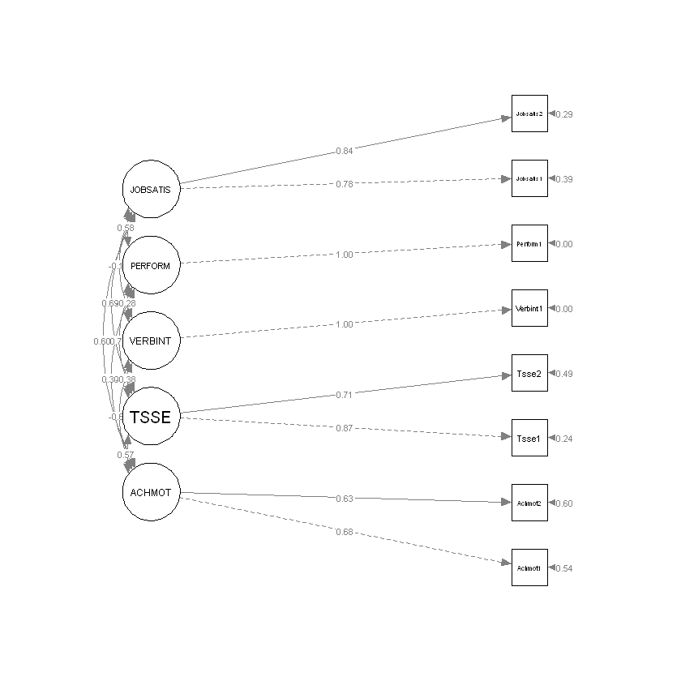

```r
semPaths(Job_CFA.B.fit, whatLabels = "std", style = "lisrel", nCharNodes = 0, rotation = 2)
```

- 대부분의 회귀계수가 통계적으로 유의

```r
summary(Job_CFA.B.fit, fit.measures = TRUE, rsquare = TRUE, standardized = TRUE)$pe %>%
    filter(pvalue >= 0.05)
```

A data.frame: 1 × 11

| lhs <chr> | op <chr> | rhs <chr> | exo <int> | est <dbl> | se <dbl> | z <dbl> | pvalue <dbl> | std.lv <dbl> | std.all <dbl> | std.nox <dbl> |
| --- | --- | --- | --- | --- | --- | --- | --- | --- | --- | --- |
| VERBINT | ~~ | JOBSATIS | 0 | -0.3975076 | 0.2035382 | -1.952988 | 0.05082102 | -0.1570099 | -0.1570099 | -0.1570099 |

- 수정지수가 10이되는 경로 없음

```r
modificationindices(Job_CFA.B.fit, sort = T) %>% filter(mi >= 10)
```

A lavaan.data.frame: 0 × 8

| lhs | op | rhs | mi | epc | sepc.lv | sepc.all | sepc.nox |
| --- | --- | --- | --- | --- | --- | --- | --- |
| <chr> | <chr> | <chr> | <dbl> | <dbl> | <dbl> | <dbl> | <dbl> |

#### 잠재변수들 간의 상관계수

```r
summary(Job_CFA.B.fit, fit.measures = TRUE, rsquare = TRUE, standardized = TRUE)$pe %>%
    filter(op == "~~") %>% filter(lhs != rhs) %>% select(lhs, rhs, std.all, pvalue)
```

A data.frame: 10 × 4

| lhs <chr> | rhs <chr> | std.all <dbl> | pvalue <dbl> |
| --- | --- | --- | --- |
| ACHMOT | TSSE | 0.5698750 | 9.117441e-07 |
| ACHMOT | VERBINT | -0.6057817 | 2.214220e-08 |
| ACHMOT | PERFORM | 0.2980026 | 1.824920e-03 |
| ACHMOT | JOBSATIS | 0.5964749 | 1.106818e-06 |
| TSSE | VERBINT | -0.3831429 | 4.607652e-06 |
| TSSE | PERFORM | 0.7177549 | 4.507505e-14 |
| TSSE | JOBSATIS | 0.6928921 | 3.195395e-10 |
| VERBINT | PERFORM | -0.2788418 | 1.455682e-04 |
| VERBINT | JOBSATIS | -0.1570099 | 5.082102e-02 |
| PERFORM | JOBSATIS | 0.5765015 | 1.566182e-09 |

## 측정모형 수정

```r
Jobsatis.B <- "

    # measurement model
    ACHMOT = ~ Achmot1 + Achmot2
    TSSE =~ Tsse1 + Tsse2
    VERBINT =~ Verbint1
    PERFORM =~ Perform1
    JOBSATIS =~ Jobsatis1 + Jobsatis2

    # regression
    PERFORM ~ TSSE + VERBINT
    JOBSATIS ~ ACHMOT + VERBINT

    # error covariance
    PERFORM ~~ 0 * JOBSATIS

    # error variance
    Verbint1 ~~ 0.509 * Verbint1
    Perform1 ~~ 0 * Perform1
"
```

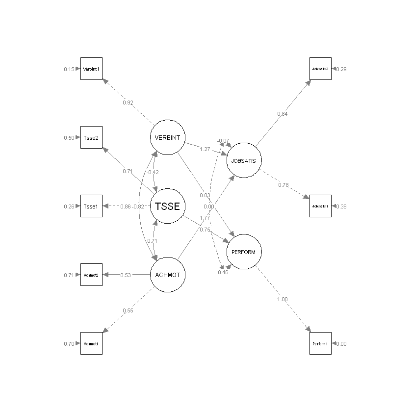

```r
Jobsatis.B.fit <- sem(Jobsatis.B, data = Jobsatis)
semPaths(Jobsatis.B.fit, whatLabels = "std", style = "lisrel", nCharNodes = 0, rotation = 2)
```

```r
tidy(fitMeasures(Jobsatis.B.fit)) %>%
    filter(names %in% c("chisq", "df", "gfi", "agfi", "cfi", "tli", "rmsea", "srmr"))
```

A tibble: 8 × 2

| names <chr> | x <lvn.vctr> |
| --- | --- |
| chisq | 34.92921208 |
| df | 15.00000000 |
| cfi | 0.96419873 |
| tli | 0.93317096 |
| rmsea | 0.08150503 |
| srmr | 0.04013597 |
| gfi | 0.96014461 |
| agfi | 0.90434706 |

- 내생 잠재변수 JOBSATIS에 대응되는 오차변수 $\zeta_2$의 분산이 음수로 추정 $\rightarrow$ 수정필요
- $PERFORM \leftarrow VERBINT$의 인과관계에 대한 회귀계수가 통계적으로 유의하지 않음 $\rightarrow$ 수정필요

```r
summary(Jobsatis.B.fit, fit.measures = TRUE, rsquare = TRUE, standardized = TRUE)$pe %>%
    filter(pvalue > 0.05)
```

A data.frame: 2 × 11

| lhs <chr> | op <chr> | rhs <chr> | exo <int> | est <dbl> | se <dbl> | z <dbl> | pvalue <dbl> | std.lv <dbl> | std.all <dbl> | std.nox <dbl> |
| --- | --- | --- | --- | --- | --- | --- | --- | --- | --- | --- |
| PERFORM | ~ | VERBINT | 0 | 0.01871361 | 0.04123291 | 0.4538514 | 0.6499358 | 0.03113431 | 0.03113431 | 0.03113431 |
| JOBSATIS | ~~ | JOBSATIS | 0 | -0.13205763 | 0.37248259 | -0.3545337 | 0.7229390 | -0.06931856 | -0.06931856 | -0.06931856 |

- 인과관계에 대한 수정지수
  - $VERBINT \leftarrow JOBSATIS$, $ACHMOT \leftarrow JOBSATIS$등의 수정지수들이 높음

    **$\rightarrow$ 우선 $JOBSATIS \leftarrow PERFORM$에 대응하는 계수 추가**

```r
modificationindices(Jobsatis.B.fit, sort = T) %>%
    filter(op == "~")
```

A lavaan.data.frame: 10 × 8

| lhs <chr> | op <chr> | rhs <chr> | mi <dbl> | epc <dbl> | sepc.lv <dbl> | sepc.all <dbl> | sepc.nox <dbl> |
| --- | --- | --- | --- | --- | --- | --- | --- |
| VERBINT | ~ | JOBSATIS | 8.4516307 | 38.84770498 | 31.69672366 | 31.69672366 | 31.69672366 |
| ACHMOT | ~ | JOBSATIS | 8.4468214 | 5.38294212 | 13.65883406 | 13.65883406 | 13.65883406 |
| TSSE | ~ | JOBSATIS | 8.4426272 | -10.05257481 | -14.93067078 | -14.93067078 | -14.93067078 |
| JOBSATIS | ~ | TSSE | 8.4418245 | 3.62406400 | 2.44002262 | 2.44002262 | 2.44002262 |
| JOBSATIS | ~ | PERFORM | 7.7290747 | 0.43637437 | 0.32146130 | 0.32146130 | 0.32146130 |
| TSSE | ~ | PERFORM | 1.3339370 | -0.16992390 | -0.18591993 | -0.18591993 | -0.18591993 |
| ACHMOT | ~ | PERFORM | 1.3339321 | 0.04403777 | 0.08231684 | 0.08231684 | 0.08231684 |
| VERBINT | ~ | PERFORM | 1.3339270 | 0.21737461 | 0.13065538 | 0.13065538 | 0.13065538 |
| PERFORM | ~ | ACHMOT | 1.3339154 | 0.41011475 | 0.21940272 | 0.21940272 | 0.21940272 |
| PERFORM | ~ | JOBSATIS | 0.8384405 | 0.08235846 | 0.11179921 | 0.11179921 | 0.11179921 |

## 05.08. 구조모형 수정

- **우선 $JOBSATIS \leftarrow PERFORM$에 대응하는 계수 추가 + $PERFORM \leftarrow VERBINT$ 제거**

```r
Jobsatis.C <- "

    # measurement model
    ACHMOT = ~ Achmot1 + Achmot2
    TSSE =~ Tsse1 + Tsse2
    VERBINT =~ Verbint1
    PERFORM =~ Perform1
    JOBSATIS =~ Jobsatis1 + Jobsatis2

    # regression
    PERFORM ~ TSSE
    JOBSATIS ~ ACHMOT + VERBINT + PERFORM

    # error covariance
    PERFORM ~~ 0 * JOBSATIS

    # error variance
    Verbint1 ~~ 0.509 * Verbint1
    Perform1 ~~ 0 * Perform1
"
```

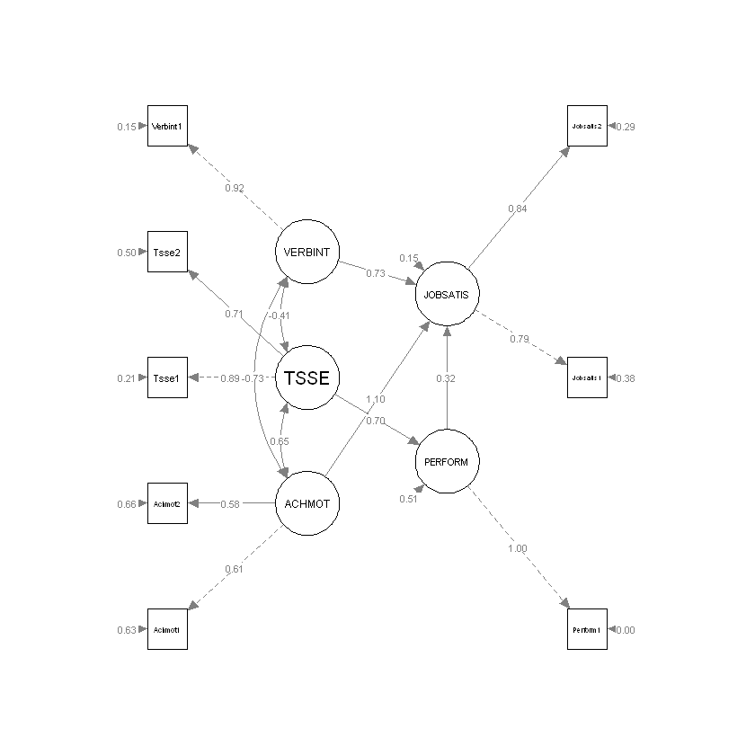

```r
Jobsatis.C.fit <- sem(Jobsatis.C, data = Jobsatis)
semPaths(Jobsatis.C.fit, whatLabels = "std", style = "lisrel", nCharNodes = 0, rotation = 2)
```

- 모든 적합도 지수들이 우수

```r
tidy(fitMeasures(Jobsatis.C.fit)) %>%
    filter(names %in% c("chisq", "df", "gfi", "agfi", "cfi", "tli", "rmsea", "srmr"))
```

A tibble: 8 × 2

| names <chr> | x <lvn.vctr> |
| --- | --- |
| chisq | 26.31483764 |
| df | 15.00000000 |
| cfi | 0.97967378 |
| tli | 0.96205772 |
| rmsea | 0.06141346 |
| srmr | 0.03753410 |
| gfi | 0.96950244 |
| agfi | 0.92680585 |

- 이전 모형에 비해 수정지수가 향상

```r
modificationindices(Jobsatis.C.fit, sort = T) %>% filter(op == "~")
# summary(Jobsatis.C.fit, fit.measures = TRUE, rsquare = TRUE, standardized = TRUE)$pe
```

A lavaan.data.frame: 10 × 8

| lhs <chr> | op <chr> | rhs <chr> | mi <dbl> | epc <dbl> | sepc.lv <dbl> | sepc.all <dbl> | sepc.nox <dbl> |
| --- | --- | --- | --- | --- | --- | --- | --- |
| ACHMOT | ~ | JOBSATIS | 7.73104193 | -0.40156450 | -0.93127817 | -0.93127817 | -0.93127817 |
| PERFORM | ~ | JOBSATIS | 6.78255315 | -0.30283770 | -0.41612701 | -0.41612701 | -0.41612701 |
| ACHMOT | ~ | PERFORM | 6.28870726 | -0.17859200 | -0.30141867 | -0.30141867 | -0.30141867 |
| TSSE | ~ | JOBSATIS | 5.55970544 | 0.79932534 | 1.16040552 | 1.16040552 | 1.16040552 |
| JOBSATIS | ~ | TSSE | 4.76407610 | 0.80643841 | 0.55550120 | 0.55550120 | 0.55550120 |
| TSSE | ~ | PERFORM | 2.68278079 | 0.31421086 | 0.33196434 | 0.33196434 | 0.33196434 |
| VERBINT | ~ | JOBSATIS | 2.01691565 | -0.53569113 | -0.44212317 | -0.44212317 | -0.44212317 |
| VERBINT | ~ | PERFORM | 1.77474794 | -0.22140720 | -0.13298559 | -0.13298559 | -0.13298559 |
| PERFORM | ~ | ACHMOT | 1.45922510 | -0.21480143 | -0.12727087 | -0.12727087 | -0.12727087 |
| PERFORM | ~ | VERBINT | 0.03364228 | -0.00768571 | -0.01279591 | -0.01279591 | -0.01279591 |

## 05.09. 경로계수에 대한 요약과 해석

- 최종모형에 대해 개별 모수 (경로계수 및 공분산)등릐 추정치에 대하여 통계적 유의성을 평가하고, 각 추정치의 부호와 크기를 고려하여 의미를 해석

### 측정모형에 대한 요약과 해석

- 인자적재값의 표준화추정치는 모두 0.5보다 크며, 통계적으로 유의

```r
summary(Jobsatis.C.fit, fit.measures = TRUE, rsquare = TRUE, standardized = TRUE)$pe %>%
    filter(op == "=~") %>% select(lhs, rhs, std.all, pvalue)
```

A data.frame: 8 × 4

| lhs <chr> | rhs <chr> | std.all <dbl> | pvalue <dbl> |
| --- | --- | --- | --- |
| ACHMOT | Achmot1 | 0.6107715 | NA |
| ACHMOT | Achmot2 | 0.5804566 | 7.071566e-11 |
| TSSE | Tsse1 | 0.8911398 | NA |
| TSSE | Tsse2 | 0.7100415 | 0.000000e+00 |
| VERBINT | Verbint1 | 0.9215046 | NA |
| PERFORM | Perform1 | 1.0000000 | NA |
| JOBSATIS | Jobsatis1 | 0.7863470 | NA |
| JOBSATIS | Jobsatis2 | 0.8430843 | 0.000000e+00 |

- 각 관찰변수에 대한 SMC는 잠재변수에 대한 측정의 신뢰도 크기를 의미하며, SMC가 대부분 0.3보다 큼

  (측정모형에서 각 관찰변수의SMC는 표준화추정치의 제곱과 같게 되며, 측정오차가 $1-SMC$로 추정)
- Verbint1에 대하여 단일지시자 문제로 인하여 신뢰도 0,85를 적용하였으므로, $SMC(Verbint1) = 0.85$가 출력
- 관찰변수 Perform1에 대하여는 오차변수의 분산을 0으로 고정하였기에 $SMC(Perform1)=1$이 출력

```r
summary(Jobsatis.C.fit, fit.measures = TRUE, rsquare = TRUE, standardized = TRUE)$pe %>%
    filter(op == 'r2')
```

A data.frame: 10 × 11

| lhs <chr> | op <chr> | rhs <chr> | exo <int> | est <dbl> | se <dbl> | z <dbl> | pvalue <dbl> | std.lv <dbl> | std.all <dbl> | std.nox <dbl> |
| --- | --- | --- | --- | --- | --- | --- | --- | --- | --- | --- |
| Verbint1 | r2 | Verbint1 | 0 | 0.8491708 | NA | NA | NA | NA | NA | NA |
| Perform1 | r2 | Perform1 | 0 | 1.0000000 | NA | NA | NA | NA | NA | NA |
| Achmot1 | r2 | Achmot1 | 0 | 0.3730418 | NA | NA | NA | NA | NA | NA |
| Achmot2 | r2 | Achmot2 | 0 | 0.3369298 | NA | NA | NA | NA | NA | NA |
| Tsse1 | r2 | Tsse1 | 0 | 0.7941302 | NA | NA | NA | NA | NA | NA |
| Tsse2 | r2 | Tsse2 | 0 | 0.5041589 | NA | NA | NA | NA | NA | NA |
| Jobsatis1 | r2 | Jobsatis1 | 0 | 0.6183415 | NA | NA | NA | NA | NA | NA |
| Jobsatis2 | r2 | Jobsatis2 | 0 | 0.7107912 | NA | NA | NA | NA | NA | NA |
| PERFORM | r2 | PERFORM | 0 | 0.4892069 | NA | NA | NA | NA | NA | NA |
| JOBSATIS | r2 | JOBSATIS | 0 | 0.8517093 | NA | NA | NA | NA | NA | NA |

### 구조모형에 대한 요약과 해석

- 모든 추정치들이 통계적으로 유의
- 내생변수 PERFORM는 설명변수 TSSE에 의해 변이중 48.9%가 설명되며, 내생변수 JOBSATIS는 3개의 설명변수에 의해 변이중 85.2%가 설명

```r
summary(Jobsatis.C.fit, fit.measures = TRUE, rsquare = TRUE, standardized = TRUE)$pe %>%
    filter(op == "r2") %>% filter(lhs %in% c("PERFORM", "JOBSATIS"))
```

A data.frame: 2 × 11

| lhs <chr> | op <chr> | rhs <chr> | exo <int> | est <dbl> | se <dbl> | z <dbl> | pvalue <dbl> | std.lv <dbl> | std.all <dbl> | std.nox <dbl> |
| --- | --- | --- | --- | --- | --- | --- | --- | --- | --- | --- |
| PERFORM | r2 | PERFORM | 0 | 0.4892069 | NA | NA | NA | NA | NA | NA |
| JOBSATIS | r2 | JOBSATIS | 0 | 0.8517093 | NA | NA | NA | NA | NA | NA |

## 05.10. 정규분포를 따르지 않는 데이터의 경우

- 구조방정식모형에 대한 계수를 추정할 때 기본이 되는 추정법은 최대우도(ML)이며,

  이 방법은 관찰변수들이 모두 정규분포를 따를 때 타당한 방법
- 정규분포로부터의 작은 이탈에는 최대우도법이 잘 작동하나, 관찰변수들 중 일부가 정규분포로부터 심하게 이탈되어 있는 경우, 최대우도법은 올바르지 않을 수 있음
- **외생 잠재변수 (Exogenous Latent Variable)** : Expect (기대수준)
- **내생 잠재변수 (Endogenous Latent Variable)** : Quality (인지품질), Value (인지가치), Satisfact (고객만족)
- **관찰변수** :
  - Expect (기대수준) : f1_1(품질기대), f1_2(요구기대), f1_3(문제기대)
  - Quality (인지품질) : f2_1 (품질평가), f2_2 (요구평가), f2_3 (문제평가)
  - Value (인지가치) : f3_1 (가격가치), f3_2 (품질가치)
  - Satisfact (고객만족) : f4_1 (전반적 만족), f4_2 (기대 대비 만족), f4_3 (이상 대비 만족)
- **내생 오차변수** : $\zeta_1, \zeta_2, \zeta_3$
- **측정 오차변수** : $\delta_1, \delta_2, \delta_3, \epsilon_1, \epsilon_2. \epsilon_3\dots, $

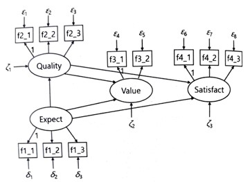

```r
Satisfact <- read.csv(paste0(getwd(), "/Data/Satisfact.csv"), header = TRUE)
Satisfact %>% head
```

A data.frame: 6 × 12

|  | f1_1 <dbl> | f1_2 <dbl> | f1_3 <dbl> | f2_1 <dbl> | f2_2 <dbl> | f2_3 <dbl> | f3_1 <dbl> | f3_2 <dbl> | f4_1 <dbl> | f4_2 <dbl> | f4_3 <dbl> | Group <int> |
| --- | --- | --- | --- | --- | --- | --- | --- | --- | --- | --- | --- | --- |
| 1 | 0.667 | 1.000 | 0.889 | 0.778 | 0.889 | 1.000 | 0.889 | 0.889 | 1.000 | 1.000 | 0.889 | 1 |
| 2 | 0.778 | 1.000 | 1.000 | 0.889 | 1.000 | 1.000 | 0.889 | 1.000 | 1.000 | 1.000 | 1.000 | 1 |
| 3 | 0.778 | 0.778 | 0.778 | 0.778 | 0.778 | 0.778 | 0.889 | 0.778 | 0.778 | 0.778 | 0.556 | 1 |
| 4 | 0.667 | 0.667 | 0.778 | 0.667 | 0.667 | 0.778 | 0.667 | 0.667 | 0.667 | 0.667 | 0.778 | 1 |
| 5 | 0.778 | 0.667 | 0.889 | 0.778 | 0.667 | 0.889 | 0.889 | 0.778 | 0.889 | 0.778 | 0.778 | 1 |
| 6 | 0.778 | 0.667 | 1.000 | 0.889 | 0.667 | 1.000 | 0.778 | 0.778 | 0.778 | 0.778 | 0.778 | 1 |

### 정규성 검토

```r
Satis.desc <- Satisfact %>% select(-Group) %>% describe
Satis.desc$skew.z <- Satis.desc$skew/sqrt(6/Satis.desc$n)
Satis.desc$kurt.z <- Satis.desc$kurtosis/sqrt(24/Satis.desc$n)
```

```r
Satis.desc
```

A psych: 11 × 15

|  | vars <int> | n <dbl> | mean <dbl> | sd <dbl> | median <dbl> | trimmed <dbl> | mad <dbl> | min <dbl> | max <dbl> | range <dbl> | skew <dbl> | kurtosis <dbl> | se <dbl> | skew.z <dbl> | kurt.z <dbl> |
| --- | --- | --- | --- | --- | --- | --- | --- | --- | --- | --- | --- | --- | --- | --- | --- |
| f1_1 | 1 | 900 | 0.8207467 | 0.1646628 | 0.778 | 0.8413625 | 0.1645686 | 0.000 | 1 | 1.000 | -1.0974850 | 2.08369005 | 0.005488760 | -13.441391 | 12.7599435 |
| f1_2 | 2 | 900 | 0.8259322 | 0.1514472 | 0.889 | 0.8419792 | 0.1645686 | 0.000 | 1 | 1.000 | -0.9754873 | 1.54732911 | 0.005048240 | -11.947231 | 9.4754170 |
| f1_3 | 3 | 900 | 0.8591244 | 0.1585015 | 0.889 | 0.8814458 | 0.1645686 | 0.000 | 1 | 1.000 | -1.4235074 | 3.25334272 | 0.005283382 | -17.434334 | 19.9225741 |
| f2_1 | 4 | 900 | 0.7354544 | 0.1816910 | 0.778 | 0.7483764 | 0.1645686 | 0.000 | 1 | 1.000 | -0.9943385 | 1.67635853 | 0.006056366 | -12.178110 | 10.2655576 |
| f2_2 | 5 | 900 | 0.7208844 | 0.1864199 | 0.778 | 0.7341722 | 0.1645686 | 0.000 | 1 | 1.000 | -0.9572760 | 1.43747896 | 0.006213996 | -11.724189 | 8.8027249 |
| f2_3 | 6 | 900 | 0.8157889 | 0.1939069 | 0.889 | 0.8455250 | 0.1645686 | 0.000 | 1 | 1.000 | -1.3869117 | 2.44586724 | 0.006463564 | -16.986129 | 14.9778168 |
| f3_1 | 7 | 900 | 0.7109878 | 0.1852185 | 0.778 | 0.7177931 | 0.1645686 | 0.000 | 1 | 1.000 | -0.5653319 | 0.11403186 | 0.006173949 | -6.923873 | 0.6982997 |
| f3_2 | 8 | 900 | 0.7237256 | 0.1623278 | 0.778 | 0.7329444 | 0.1645686 | 0.111 | 1 | 0.889 | -0.5781631 | 0.09391207 | 0.005410928 | -7.081022 | 0.5750916 |
| f4_1 | 9 | 900 | 0.7457156 | 0.1644899 | 0.778 | 0.7581125 | 0.1645686 | 0.000 | 1 | 1.000 | -0.8925695 | 1.38086497 | 0.005482998 | -10.931699 | 8.4560365 |
| f4_2 | 10 | 900 | 0.7165600 | 0.1767439 | 0.778 | 0.7283042 | 0.1645686 | 0.000 | 1 | 1.000 | -0.7662295 | 0.60933416 | 0.005891465 | -9.384357 | 3.7313944 |
| f4_3 | 11 | 900 | 0.7065778 | 0.1747089 | 0.778 | 0.7178306 | 0.1645686 | 0.000 | 1 | 1.000 | -0.8434128 | 1.32466484 | 0.005823632 | -10.329655 | 8.1118823 |

### WLS (가중최소제곱) 방법

- **관찰변수들에 대하여 특별한 분포를 가정하지 않는 비모수적 방법**

#### `sem()`의 `estimator`을 `"WLS"`로 입력

```r
Satisfact.A <- "
    # measurement model
    Expect =~ f1_1 + f1_2 + f1_3
    Quality =~ f2_1 + f2_2 + f2_3
    Value =~ f3_1 + f3_2
    Satisfact =~ f4_1 + f4_2 + f4_3

    # regression
    Quality ~ Expect
    Value ~ Expect + Quality
    Satisfact ~ Expect + Quality

    # error covariance
    Value ~~ 0 * Satisfact
"
```

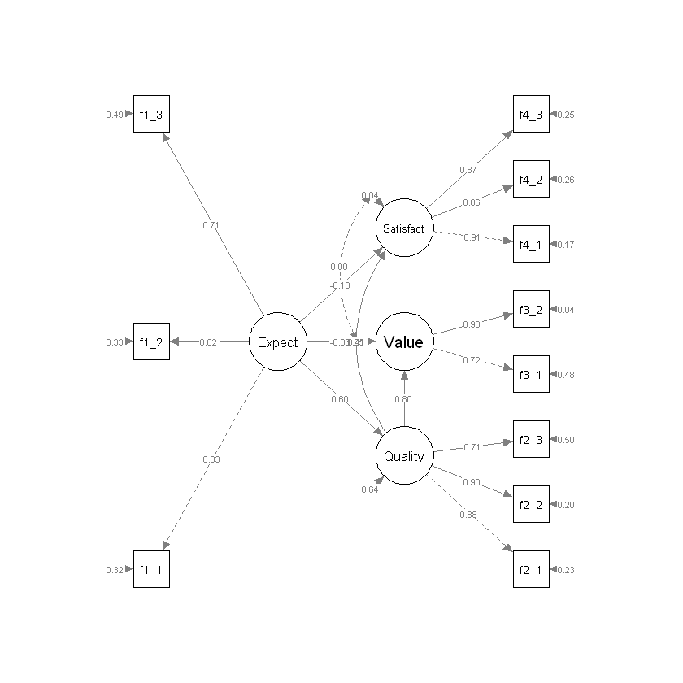

```r
Satisfact.A.fit <- sem(Satisfact.A, Satisfact, estimator = "WLS")
semPaths(Satisfact.A.fit, whatLabels = "std", style = "lisrel", nCharNodes = 0, rotation = 2)
```

- 대부분의 적합도 지수들이 좋지 않음

```r
tidy(fitMeasures(Satisfact.A.fit)) %>%
    filter(names %in% c("chisq", "df", "gfi", "agfi", "cfi", "tli", "rmsea", "srmr"))
```

A tibble: 8 × 2

| names <chr> | x <lvn.vctr> |
| --- | --- |
| chisq | 228.19941979 |
| df | 39.00000000 |
| cfi | 0.74903282 |
| tli | 0.64607192 |
| rmsea | 0.07345946 |
| srmr | 0.07759125 |
| gfi | 0.84661950 |
| agfi | 0.74043301 |

## 05.11 오차변수들 간의 연관관계

- **내생오차변수** : 모형에 포함되어 있는 인과관계로는 설명될 수 없으나, 내생 잠재변수의 변이를 발생시키는 원인으로 모형에 도입되는 일종의 외생변수
- **측정오차변수** : 측정값 중 잠재변수와 구별되는 부분
- 수정지수 확인
  - 'f1_3 $\sim\sim$ f2_3' ($\delta_3 \leftrightarrow \epsilon_3$), 'f2_1 $\sim\sim$ f2_2' ($\epsilon_1 \leftrightarrow \epsilon_2$), 'Value $\sim\sim$ Satisfact'($\zeta_2 \leftrightarrow \zeta_3$) 등에서 높은 수정지수 확인

    **오차변수들 간의 연관관계에 해당**
- **기본적으로 구조방정식모형에서는 오차변수들 간에 서로 독립을 가정함**

  **그러나 설명할 수 있는 이유가 존재한다면, 오차변수들 간에 연관관계가 존재할 수 도 있음**

```r
modificationindices(Satisfact.A.fit, sort = T) %>% filter(mi >= 10)
```

A lavaan.data.frame: 16 × 8

| lhs <chr> | op <chr> | rhs <chr> | mi <dbl> | epc <dbl> | sepc.lv <dbl> | sepc.all <dbl> | sepc.nox <dbl> |
| --- | --- | --- | --- | --- | --- | --- | --- |
| f1_3 | ~~ | f2_3 | 73.82541 | 0.007314792 | 0.007314792 | 0.5769751 | 0.5769751 |
| f2_1 | ~~ | f2_2 | 48.87300 | 0.005003940 | 0.005003940 | 0.8394296 | 0.8394296 |
| Value | ~ | Satisfact | 46.84722 | 4.686405804 | 5.268550848 | 5.2685508 | 5.2685508 |
| Value | ~~ | Satisfact | 46.84674 | 0.003572093 | 1.575532867 | 1.5755329 | 1.5755329 |
| Satisfact | ~ | Value | 46.84674 | 0.529684445 | 0.471157312 | 0.4711573 | 0.4711573 |
| f1_1 | ~~ | f2_2 | 23.18410 | -0.003068182 | -0.003068182 | -0.5120141 | -0.5120141 |
| f4_1 | ~~ | f4_3 | 23.07852 | -0.001911833 | -0.001911833 | -0.3585733 | -0.3585733 |
| f2_3 | ~~ | f3_1 | 22.65288 | -0.003276804 | -0.003276804 | -0.2185020 | -0.2185020 |
| Quality | =~ | f4_2 | 18.39656 | -1.034674886 | -0.151260653 | -0.8999209 | -0.8999209 |
| f1_2 | ~~ | f2_2 | 17.01755 | 0.002564550 | 0.002564550 | 0.4392736 | 0.4392736 |
| Value | =~ | f4_1 | 15.84581 | 0.232903353 | 0.029917943 | 0.1890537 | 0.1890537 |
| Value | =~ | f2_3 | 15.67133 | -0.318535425 | -0.040917937 | -0.2356114 | -0.2356114 |
| f1_1 | ~~ | f2_1 | 15.40500 | 0.001990530 | 0.001990530 | 0.3124129 | 0.3124129 |
| f1_2 | ~~ | f2_3 | 13.23578 | -0.002103351 | -0.002103351 | -0.2197986 | -0.2197986 |
| f4_1 | ~~ | f4_2 | 12.91101 | 0.001644433 | 0.001644433 | 0.2974944 | 0.2974944 |
| Satisfact | =~ | f3_2 | 10.15170 | 1.486186659 | 0.214625162 | 1.3572252 | 1.3572252 |

### 측정 오차변수들 간의 연관관계

- 수정지수들을 기초로 오차변수들 간의 연관관계 3개가 추가

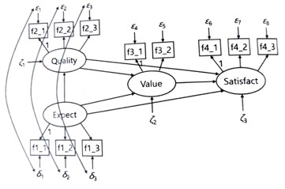

- **f1_1과 f2_1, f1_2과 f2_2, f1_1과 f2_1의 상관관계가 높음 $\rightarrow$ 관찰변수들의 측정오차 간에 서로 연관관계가 존재할 가능성 존재**

```r
cor(Satisfact %>% select(-Group))
```

A matrix: 11 × 11 of type dbl

|  | f1_1 | f1_2 | f1_3 | f2_1 | f2_2 | f2_3 | f3_1 | f3_2 | f4_1 | f4_2 | f4_3 |
| --- | --- | --- | --- | --- | --- | --- | --- | --- | --- | --- | --- |
| f1_1 | 1.0000000 | 0.6153104 | 0.4811829 | 0.4179384 | 0.2974664 | 0.3166639 | 0.2123921 | 0.2954559 | 0.3719098 | 0.2767346 | 0.2901634 |
| f1_2 | 0.6153104 | 1.0000000 | 0.4741486 | 0.2892541 | 0.3670805 | 0.2211067 | 0.2311308 | 0.2835549 | 0.3272790 | 0.2455037 | 0.2530694 |
| f1_3 | 0.4811829 | 0.4741486 | 1.0000000 | 0.2461245 | 0.2279286 | 0.4439015 | 0.2240686 | 0.2475869 | 0.2747207 | 0.1971366 | 0.2353437 |
| f2_1 | 0.4179384 | 0.2892541 | 0.2461245 | 1.0000000 | 0.7551493 | 0.5549481 | 0.4005083 | 0.5755277 | 0.6906005 | 0.6637070 | 0.6667683 |
| f2_2 | 0.2974664 | 0.3670805 | 0.2279286 | 0.7551493 | 1.0000000 | 0.5151892 | 0.3996052 | 0.5653077 | 0.6600607 | 0.6573629 | 0.6601379 |
| f2_3 | 0.3166639 | 0.2211067 | 0.4439015 | 0.5549481 | 0.5151892 | 1.0000000 | 0.2800692 | 0.4500464 | 0.5392752 | 0.5170975 | 0.5465357 |
| f3_1 | 0.2123921 | 0.2311308 | 0.2240686 | 0.4005083 | 0.3996052 | 0.2800692 | 1.0000000 | 0.7003132 | 0.4892605 | 0.4482847 | 0.4745963 |
| f3_2 | 0.2954559 | 0.2835549 | 0.2475869 | 0.5755277 | 0.5653077 | 0.4500464 | 0.7003132 | 1.0000000 | 0.6653135 | 0.6283387 | 0.6471609 |
| f4_1 | 0.3719098 | 0.3272790 | 0.2747207 | 0.6906005 | 0.6600607 | 0.5392752 | 0.4892605 | 0.6653135 | 1.0000000 | 0.7747062 | 0.7308876 |
| f4_2 | 0.2767346 | 0.2455037 | 0.1971366 | 0.6637070 | 0.6573629 | 0.5170975 | 0.4482847 | 0.6283387 | 0.7747062 | 1.0000000 | 0.7646481 |
| f4_3 | 0.2901634 | 0.2530694 | 0.2353437 | 0.6667683 | 0.6601379 | 0.5465357 | 0.4745963 | 0.6471609 | 0.7308876 | 0.7646481 | 1.0000000 |

**'$\delta_1 \leftrightarrow \epsilon_1$, $\delta_2 \leftrightarrow \epsilon_2$, $\delta_3 \leftrightarrow \epsilon_3$과 'Satisfact $\leftarrow$ Value'**를 추가하여 수정 모형 구축

```r
Satisfact.B <- "
    # measurement model
    Expect =~ f1_1 + f1_2 + f1_3
    Quality =~ f2_1 + f2_2 + f2_3
    Value =~ f3_1 + f3_2
    Satisfact =~ f4_1 + f4_2 + f4_3

    # regression
    Quality ~ Expect
    Value ~ Expect + Quality
    Satisfact ~ Expect + Quality + Value

    # error covariance
    f1_1 ~~ f2_1
    f1_2 ~~ f2_2
    f1_3 ~~ f2_3
"
```

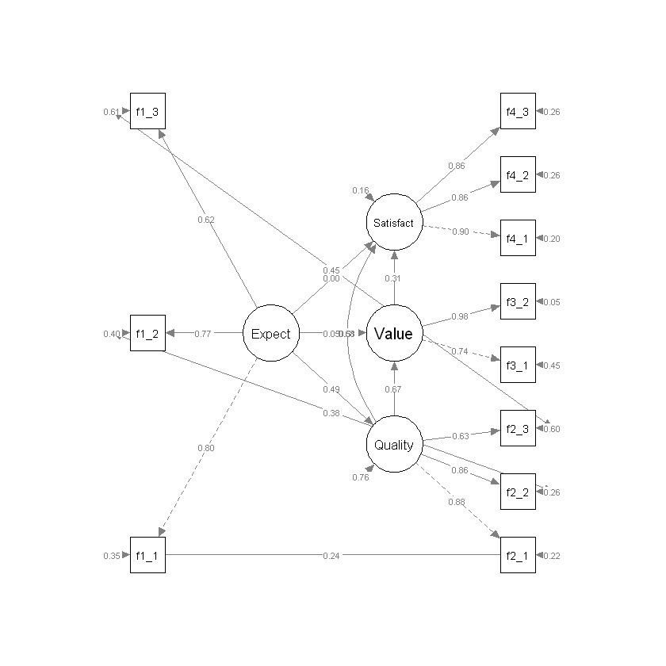

```r
Satisfact.B.fit <- sem(Satisfact.B, Satisfact, estimator = "WLS")
semPaths(Satisfact.B.fit, whatLabels = "std", style = "lisrel", nCharNodes = 0, rotation = 2)
```

- 적합도 지수들이 향상

```r
tidy(fitMeasures(Satisfact.B.fit)) %>%
    filter(names %in% c("chisq", "df", "gfi", "agfi", "cfi", "tli", "rmsea", "srmr"))
```

A tibble: 8 × 2

| names <chr> | x <lvn.vctr> |
| --- | --- |
| chisq | 71.94022977 |
| df | 35.00000000 |
| cfi | 0.95099993 |
| tli | 0.92299988 |
| rmsea | 0.03426383 |
| srmr | 0.05700565 |
| gfi | 0.95164655 |
| agfi | 0.90881922 |

- 인자적재값 : 모든 인자적재값의 표준화추정치는 0.5보다 크며, 통계적으로 유의

  (인자적재값이 유의하지 않으면 측정의 신뢰도가 의심)

```r
summary(Satisfact.B.fit, fit.measures = TRUE, rsquare = TRUE, standardized = TRUE)$pe %>%
    filter(op == '=~')
```

A data.frame: 11 × 11

| lhs <chr> | op <chr> | rhs <chr> | exo <int> | est <dbl> | se <dbl> | z <dbl> | pvalue <dbl> | std.lv <dbl> | std.all <dbl> | std.nox <dbl> |
| --- | --- | --- | --- | --- | --- | --- | --- | --- | --- | --- |
| Expect | =~ | f1_1 | 0 | 1.0000000 | 0.00000000 | NA | NA | 0.12227669 | 0.8042521 | 0.8042521 |
| Expect | =~ | f1_2 | 0 | 0.9306111 | 0.05896917 | 15.78132 | 0 | 0.11379204 | 0.7732711 | 0.7732711 |
| Expect | =~ | f1_3 | 0 | 0.7883535 | 0.06204985 | 12.70516 | 0 | 0.09639726 | 0.6223564 | 0.6223564 |
| Quality | =~ | f2_1 | 0 | 1.0000000 | 0.00000000 | NA | NA | 0.15445308 | 0.8830504 | 0.8830504 |
| Quality | =~ | f2_2 | 0 | 0.9973927 | 0.03839993 | 25.97382 | 0 | 0.15405038 | 0.8601603 | 0.8601603 |
| Quality | =~ | f2_3 | 0 | 0.7366998 | 0.04826797 | 15.26271 | 0 | 0.11378556 | 0.6328413 | 0.6328413 |
| Value | =~ | f3_1 | 0 | 1.0000000 | 0.00000000 | NA | NA | 0.13421333 | 0.7394858 | 0.7394858 |
| Value | =~ | f3_2 | 0 | 1.1410770 | 0.05856839 | 19.48281 | 0 | 0.15314775 | 0.9765845 | 0.9765845 |
| Satisfact | =~ | f4_1 | 0 | 1.0000000 | 0.00000000 | NA | NA | 0.14197226 | 0.8966537 | 0.8966537 |
| Satisfact | =~ | f4_2 | 0 | 1.0128056 | 0.03006924 | 33.68245 | 0 | 0.14379030 | 0.8617231 | 0.8617231 |
| Satisfact | =~ | f4_3 | 0 | 0.9963583 | 0.03015964 | 33.03615 | 0 | 0.14145524 | 0.8581228 | 0.8581228 |

- 관찰변수에 대한 모든 SMC가 0.3보다 높음

```r
summary(Satisfact.B.fit, fit.measures = TRUE, rsquare = TRUE, standardized = TRUE)$pe %>%
    filter(op == 'r2') %>% filter(str_detect(lhs, "_"))
```

A data.frame: 11 × 11

| lhs <chr> | op <chr> | rhs <chr> | exo <int> | est <dbl> | se <dbl> | z <dbl> | pvalue <dbl> | std.lv <dbl> | std.all <dbl> | std.nox <dbl> |
| --- | --- | --- | --- | --- | --- | --- | --- | --- | --- | --- |
| f1_1 | r2 | f1_1 | 0 | 0.6468214 | NA | NA | NA | NA | NA | NA |
| f1_2 | r2 | f1_2 | 0 | 0.5979481 | NA | NA | NA | NA | NA | NA |
| f1_3 | r2 | f1_3 | 0 | 0.3873275 | NA | NA | NA | NA | NA | NA |
| f2_1 | r2 | f2_1 | 0 | 0.7797780 | NA | NA | NA | NA | NA | NA |
| f2_2 | r2 | f2_2 | 0 | 0.7398757 | NA | NA | NA | NA | NA | NA |
| f2_3 | r2 | f2_3 | 0 | 0.4004881 | NA | NA | NA | NA | NA | NA |
| f3_1 | r2 | f3_1 | 0 | 0.5468393 | NA | NA | NA | NA | NA | NA |
| f3_2 | r2 | f3_2 | 0 | 0.9537173 | NA | NA | NA | NA | NA | NA |
| f4_1 | r2 | f4_1 | 0 | 0.8039878 | NA | NA | NA | NA | NA | NA |
| f4_2 | r2 | f4_2 | 0 | 0.7425666 | NA | NA | NA | NA | NA | NA |
| f4_3 | r2 | f4_3 | 0 | 0.7363747 | NA | NA | NA | NA | NA | NA |

- 오차변수의 연관관계 : 3개의 경로에 대해서 공분산 추정치가 통계적으로 유의하며, 상관계수가 0.2이상의 값을 가짐

```r
summary(Satisfact.B.fit, fit.measures = TRUE, rsquare = TRUE, standardized = TRUE)$pe %>%
    filter(op == '~~') %>% head(3)
```

A data.frame: 3 × 11

|  | lhs <chr> | op <chr> | rhs <chr> | exo <int> | est <dbl> | se <dbl> | z <dbl> | pvalue <dbl> | std.lv <dbl> | std.all <dbl> | std.nox <dbl> |
| --- | --- | --- | --- | --- | --- | --- | --- | --- | --- | --- | --- |
| 1 | f1_1 | ~~ | f2_1 | 0 | 0.001813897 | 0.0005083218 | 3.568403 | 3.591640e-04 | 0.001813897 | 0.2445809 | 0.2445809 |
| 2 | f1_2 | ~~ | f2_2 | 0 | 0.003234523 | 0.0006327766 | 5.111635 | 3.193832e-07 | 0.003234523 | 0.3795030 | 0.3795030 |
| 3 | f1_3 | ~~ | f2_3 | 0 | 0.007599784 | 0.0008422630 | 9.023053 | 0.000000e+00 | 0.007599784 | 0.4502671 | 0.4502671 |

- 구조모형의 회귀계수 추정치 : 통계적으로 유의하지 않은 계수 존재 $\rightarrow$ 모형 수정 고려 가능

```r
summary(Satisfact.B.fit, fit.measures = TRUE, rsquare = TRUE, standardized = TRUE)$pe %>%
    filter(op == '~')
```

A data.frame: 6 × 11

| lhs <chr> | op <chr> | rhs <chr> | exo <int> | est <dbl> | se <dbl> | z <dbl> | pvalue <dbl> | std.lv <dbl> | std.all <dbl> | std.nox <dbl> |
| --- | --- | --- | --- | --- | --- | --- | --- | --- | --- | --- |
| Quality | ~ | Expect | 0 | 0.615053011 | 0.05652476 | 10.8811246 | 0.000000e+00 | 0.486922266 | 0.486922266 | 0.486922266 |
| Value | ~ | Expect | 0 | 0.056529947 | 0.04061281 | 1.3919240 | 1.639454e-01 | 0.051502296 | 0.051502296 | 0.051502296 |
| Value | ~ | Quality | 0 | 0.582216272 | 0.04823391 | 12.0706838 | 0.000000e+00 | 0.670016144 | 0.670016144 | 0.670016144 |
| Satisfact | ~ | Expect | 0 | 0.004128043 | 0.03854748 | 0.1070898 | 9.147177e-01 | 0.003555366 | 0.003555366 | 0.003555366 |
| Satisfact | ~ | Quality | 0 | 0.623512836 | 0.05328210 | 11.7021068 | 0.000000e+00 | 0.678326013 | 0.678326013 | 0.678326013 |
| Satisfact | ~ | Value | 0 | 0.323301543 | 0.04336178 | 7.4559106 | 8.926193e-14 | 0.305632774 | 0.305632774 | 0.305632774 |

### 내생 오차변수들 간의 연관관계

- **내생 오차변수들 간의 연관관계 : 오차들 간의 연관성이라는 단순한 의미가 아닌, 관련된 설명변수들이 통제된 상황에서, 내생변수들 간의 편상관으로 해석되어야 함**

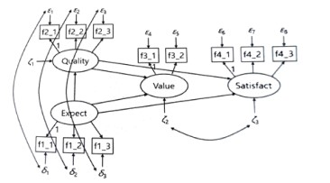

- **위 모형은 'Satisfact $\leftarrow$ Value' 대신, '$\zeta_2 \leftarrow \zeta_3$'가 설정되어 있음**

  **'Satisfact $\leftarrow$ Value'가 설정된 모형과 위 모형은 동치관계 $\rightarrow$ 동일한 적합도 지수**

```r
Satisfact.C <- "
    # measurement model
    Expect =~ f1_1 + f1_2 + f1_3
    Quality =~ f2_1 + f2_2 + f2_3
    Value =~ f3_1 + f3_2
    Satisfact =~ f4_1 + f4_2 + f4_3

    # regression
    Quality ~ Expect
    Value ~ Expect + Quality
    Satisfact ~ Expect + Quality

    # error covariance
    Value ~~ Satisfact
    f1_1 ~~ f2_1
    f1_2 ~~ f2_2
    f1_3 ~~ f2_3
"
```

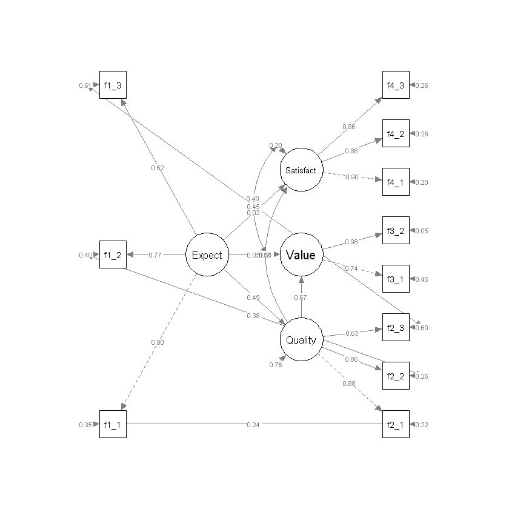

```r
Satisfact.C.fit <- sem(Satisfact.C, Satisfact, estimator = "WLS")
semPaths(Satisfact.C.fit, whatLabels = "std", style = "lisrel", nCharNodes = 0, rotation = 2)
```

```r
tidy(fitMeasures(Satisfact.C.fit)) %>%
    filter(names %in% c("chisq", "df", "gfi", "agfi", "cfi", "tli", "rmsea", "srmr"))
```

A tibble: 8 × 2

| names <chr> | x <lvn.vctr> |
| --- | --- |
| chisq | 71.94022977 |
| df | 35.00000000 |
| cfi | 0.95099993 |
| tli | 0.92299988 |
| rmsea | 0.03426383 |
| srmr | 0.05700557 |
| gfi | 0.95164655 |
| agfi | 0.90881922 |

- Value $\sim\sim$ Satisfact의 공분산과 편상관 계수 : 두 오차변수 $\zeta_2, \zeta_3$간의 상관계수 0.487은 대응되는 내생변수 간의 편상관(연관관계)로 해석

```r
summary(Satisfact.C.fit, fit.measures = TRUE, rsquare = TRUE, standardized = TRUE)$pe %>%
    filter(op == '~~') %>% head(1) %>% select(lhs, op, rhs, est, std.lv)
```

A data.frame: 1 × 5

|  | lhs <chr> | op <chr> | rhs <chr> | est <dbl> | std.lv <dbl> |
| --- | --- | --- | --- | --- | --- |
| 1 | Value | ~~ | Satisfact | 0.002998167 | 0.4865311 |

- 회귀계수 추정치와 SMC는 조금씩 달라짐

#### 동치모형은 동일한 적합도와 자유도를 가지므로, 적합도만으로는 동치관계에 있는 모형들 중 어느 것이 더 우수한지를 결정할 수 없음